# Project Python Foundations: FoodHub Data Analysis

### **Question 8**: Which is the most popular cuisine on weekends? [1 mark]

```python
# Write the code here
data.groupby(['day_of_the_week'])['cuisine_type'].value_counts()
```

```
day_of_the_week  cuisine_type
Weekday          American          169
                 Japanese          135
                 Italian            91
                 Chinese            52
                 Mexican            24
                 Indian             24
                 Middle Eastern     17
                 Mediterranean      14
                 Southern            6
                 French              5
                 Thai                4
                 Vietnamese          3
                 Korean              2
                 Spanish             1
Weekend          American          415
                 Japanese          335
                 Italian           207
                 Chinese           163
                 Mexican            53
                 Indian             49
                 Middle Eastern     32
                 Mediterranean      32
                 Thai               15
                 French             13
                 Korean             11
                 Southern           11
                 Spanish            11
                 Vietnamese          4
Name: count, dtype: int64
```

#### Observations:

On weekends, the most popular cusine is American

### **Question 9**: What percentage of the orders cost more than 20 dollars? [2 marks]

```python
# Write the code here
# find data with cost greater than 20
data_cost_greater_than_20 = data[data['cost_of_the_order'] > 20]

#Reset index for the new DataFrame
data_cost_greater_than_20.reset_index(inplace=True)

# get the percentage by diving above number of rows with total number of rows and multiplying by 100
percentage_cost_of_order = (data[data['cost_of_the_order'] > 20].shape[0] / data.shape[0])*100

#Printing the percentage
print("Percentage of orders above 20 dollars : ${:.2f}".format(percentage_cost_of_order))

# Printing the data
print("The orders above 20 dollars :")
data_cost_greater_than_20
```

```
Percentage of orders above 20 dollars : $29.24
The orders above 20 dollars :
```

|  | index | order_id | customer_id | restaurant_name | cuisine_type | cost_of_the_order | day_of_the_week | rating | food_preparation_time | delivery_time |
| --- | --- | --- | --- | --- | --- | --- | --- | --- | --- | --- |
| 0 | 0 | 1477147 | 337525 | Hangawi | Korean | 30.75 | Weekend | 3 | 25 | 20 |
| 1 | 3 | 1477334 | 106968 | Blue Ribbon Fried Chicken | American | 29.20 | Weekend | 3 | 25 | 15 |
| 2 | 5 | 1477224 | 147468 | Tamarind TriBeCa | Indian | 25.22 | Weekday | 3 | 20 | 24 |
| 3 | 12 | 1476966 | 129969 | Blue Ribbon Fried Chicken | American | 24.30 | Weekend | 5 | 23 | 17 |
| 4 | 17 | 1477373 | 139885 | Blue Ribbon Sushi Izakaya | Japanese | 33.03 | Weekend | 4 | 21 | 22 |
| ... | ... | ... | ... | ... | ... | ... | ... | ... | ... | ... |
| 550 | 1884 | 1477437 | 304993 | Shake Shack | American | 31.43 | Weekend | 3 | 31 | 24 |
| 551 | 1885 | 1477550 | 97324 | Shake Shack | American | 29.05 | Weekday | 4 | 27 | 29 |
| 552 | 1892 | 1477473 | 97838 | Han Dynasty | Chinese | 29.15 | Weekend | 4 | 29 | 21 |
| 553 | 1893 | 1476701 | 292602 | Chipotle Mexican Grill $1.99 Delivery | Mexican | 22.31 | Weekend | 5 | 31 | 17 |
| 554 | 1895 | 1477819 | 35309 | Blue Ribbon Sushi | Japanese | 25.22 | Weekday | 4 | 31 | 24 |

555 rows × 10 columns

#### Observations:

29.24 % of orders cost above 20 dollars

### **Question 10**: What is the mean order delivery time? [1 mark]

```python
# Write the code here
print("The mean order delivery time is : ",round(data['delivery_time'].mean(),2),"minutes")
```

```
The mean order delivery time is :  24.16 minutes
```

#### Observations:

The mean order delivery time is 24.16 minutes

### **Question 11:** The company has decided to give 20% discount vouchers to the top 3 most frequent customers. Find the IDs of these customers and the number of orders they placed. [1 mark]

```python
# Write the code here
data['customer_id'].value_counts()[:3]
```

```
customer_id
52832    13
47440    10
83287     9
Name: count, dtype: int64
```

#### Observations:

The top 3 most frequent customers are with customer id

52832 with 13 orders

47440 with 10 orders

83287 with 9 orders

### **Question 12**: Perform a multivariate analysis to explore relationships between the important variables in the dataset. (It is a good idea to explore relations between numerical variables as well as relations between numerical and categorical variables) [10 marks]

### Heat Map for the Numerical Data

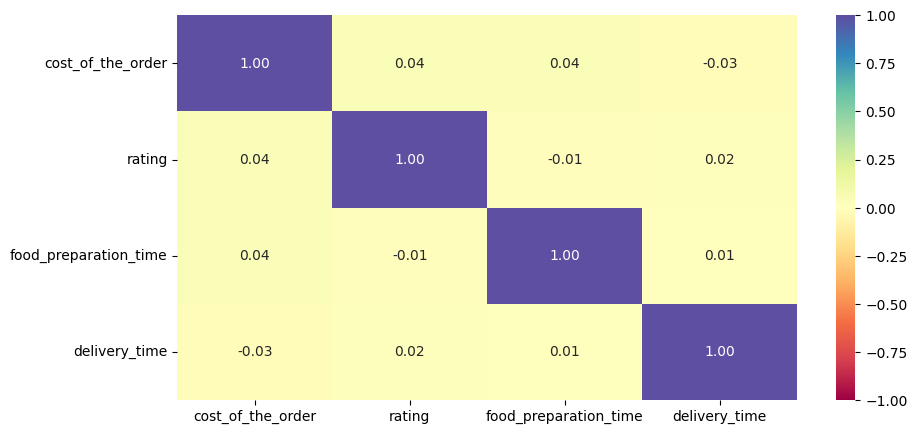

```python
# Write the code here
plt.figure(figsize=(10,5))
sns.heatmap(data=data[['cost_of_the_order','rating','food_preparation_time','delivery_time']].corr(),annot=True,cmap='Spectral',vmin=-1,vmax=1,fmt=".2f")
plt.show()
```

Observation:

There seems to be a very light positive correlation between cost of the order with rating and food preparation time.

A light negative correlation between cost of the order and delivery time

### Cuisine vs Cost of the order

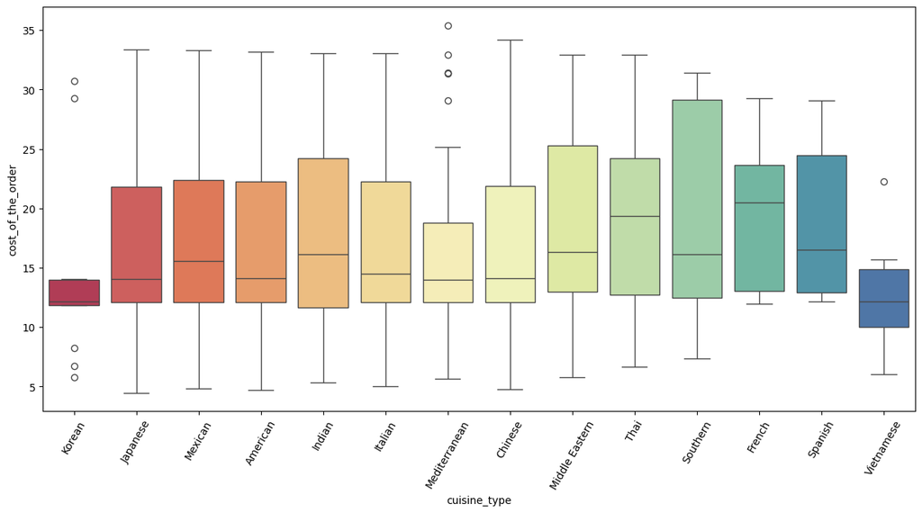

```python
# Relationship between cost of the order and cuisine type
plt.figure(figsize=(15,7))
sns.boxplot(x = "cuisine_type", y = "cost_of_the_order", data = data, palette = 'Spectral', hue = "cuisine_type")
plt.xticks(rotation = 60)
plt.show()
```

### Observation

- Korean and Vietnamese cuisine seems to have lower cost of the order
- French Cuisine has highest Median for the cost of the order
- Korean,Vietnamese and Mediterranean Cuisine have some very high outliers
- Southern Cuisine seems to have a long interquartile range meaning a significant right skewness in the cost of the order than other cusine types

### Cuisine vs Food Preparation time

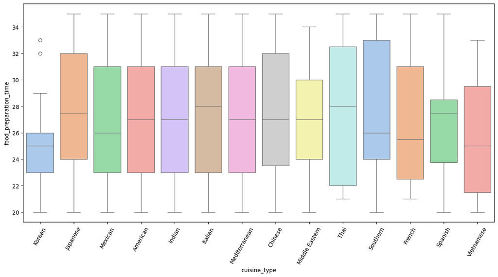

```python
# Relationship between food preparation time and cuisine type
plt.figure(figsize=(15,7))
sns.boxplot(x = "cuisine_type", y = "food_preparation_time", data = data, palette = 'pastel', hue = "cuisine_type")
plt.xticks(rotation = 60)
plt.show()
```

### Observation

- Korean Cuisine takes lesser food preparation type.
- Thai and French Cusine take 21 mins mininum for food preparation
- Vitenamese and Middle eastern Cuisine takes maximum time of 33 and 34 minutes to prepare time respectively
- All the other cusuine types take minimum of 20 mins to maximum 35 mins for food preparation

### Cuisine vs Delivery time

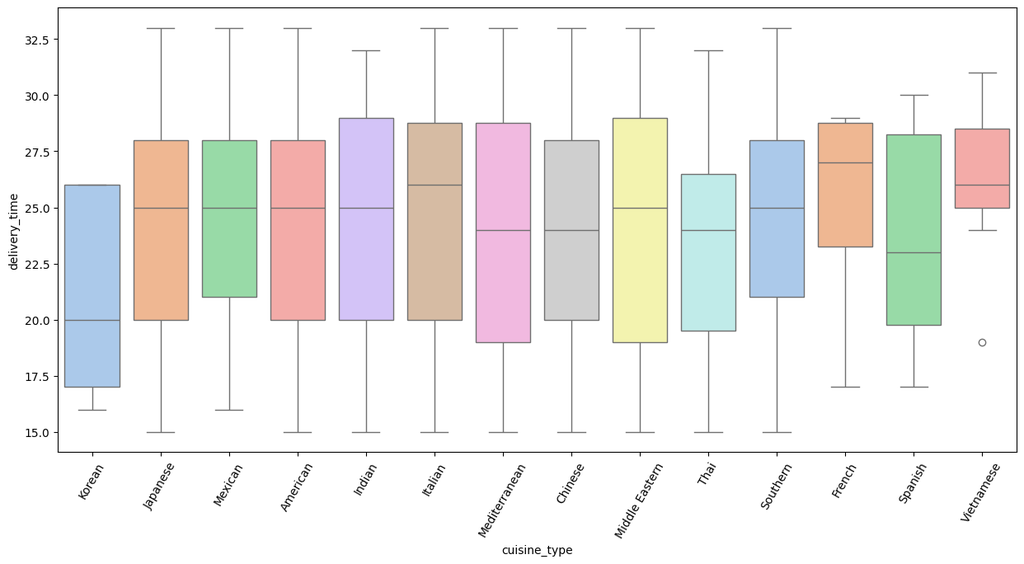

```python
# Relationship between delivery  time and cuisine type
plt.figure(figsize=(15,7))
sns.boxplot(x = "cuisine_type", y = "delivery_time", data = data, palette = 'pastel', hue = "cuisine_type")
plt.xticks(rotation = 60)
plt.show()
```

#### Day of the Week vs Delivery time

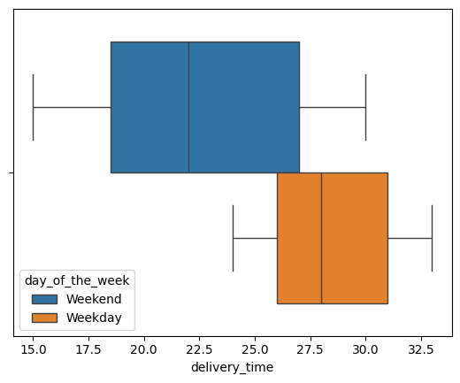

```python
# Relationship between day of the week and delivery time
sns.boxplot(data=data, x = 'delivery_time' , hue = 'day_of_the_week')
plt.show()
```

### Observation

- Delivery time for the food is lesser on Weekend than on Weekdays
- Median time on Weekend is 22 minutes while on Weekday it is 28 mins

### Observations on the Top 5 revenue generating restaurants:

```python
data.groupby(['restaurant_name'])['cost_of_the_order'].sum().sort_values(ascending=False).head()
```

```
restaurant_name
Shake Shack                  3579.53
The Meatball Shop            2145.21
Blue Ribbon Sushi            1903.95
Blue Ribbon Fried Chicken    1662.29
Parm                         1112.76
Name: cost_of_the_order, dtype: float64
```

### Observation

The top revenue generating restaurants are

1. Shake Shack $ 3579.53
2. The Meatball Shop $ 2145.21
3. Blue Ribbon Sushi $ 1903.95
4. Blue Ribbon Fried Chicken $ 1662.29
5. Parm $ 1112.76

### Rating vs Delivery time

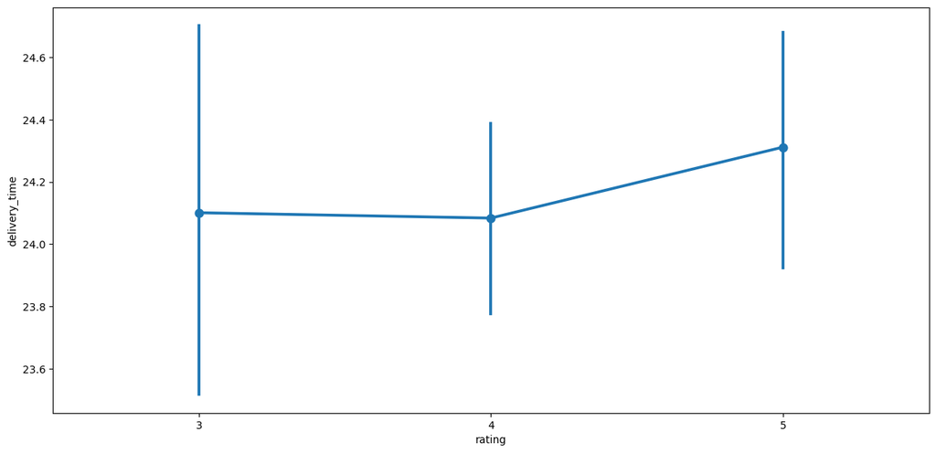

```python
# Relationship between rating and delivery time
plt.figure(figsize=(15, 7))
sns.pointplot(x = 'rating', y = 'delivery_time', data = data)
plt.show()
```

### Observation

Observing Lower Delivery time for order rated 3 and 4

### Rating vs Food preparation time

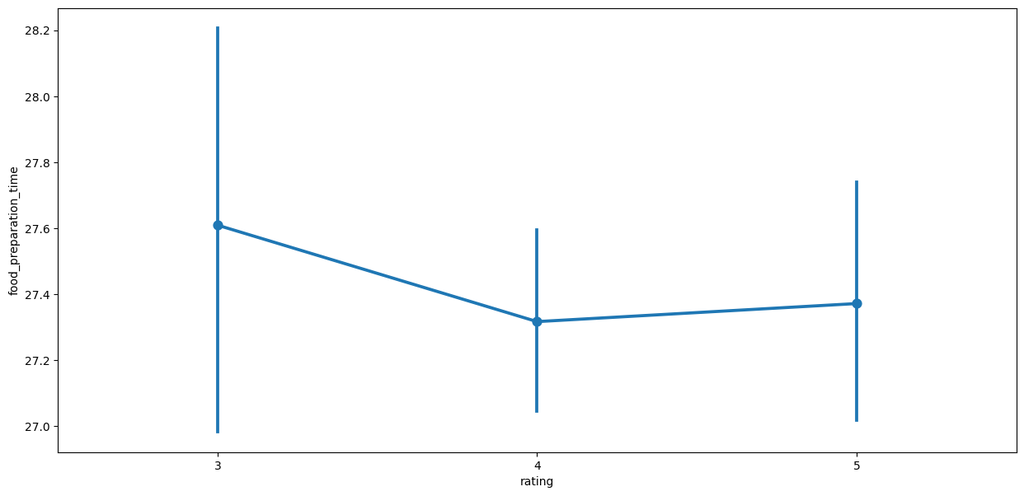

```python
# Relationship between rating and food preparation time
plt.figure(figsize=(15, 7))
sns.pointplot(x = 'rating', y = 'food_preparation_time', data = data)
plt.show()
```

### Observation

Lower Food Preparation time is for high rated orders (4 and 5)

### Rating vs Cost of the order

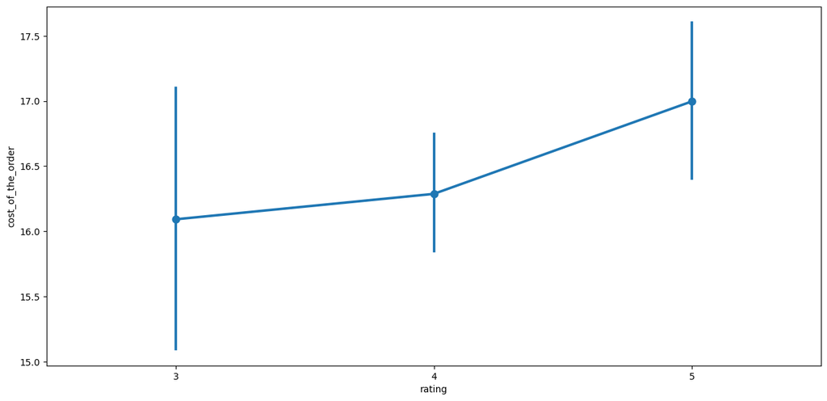

```python
# Relationship between rating and cost of the order
plt.figure(figsize=(15, 7))
sns.pointplot(x = 'rating', y = 'cost_of_the_order', data = data)
plt.show()
```

### Observation

Customers seems to have rated 5.0 for high cost of the order (17.0 $)

### **Question 13:** The company wants to provide a promotional offer in the advertisement of the restaurants. The condition to get the offer is that the restaurants must have a rating count of more than 50 and the average rating should be greater than 4. Find the restaurants fulfilling the criteria to get the promotional offer. [3 marks]

```python
# Write the code here
# 'Not given' in rating is already converted to np.nan during Question 3 and data type converted to float
# Create a data frame with rating count and average rating column. Rating count takes total number of countsand average_rating takes mean of ratings when grouped by different restaurants
grouped_data = data.groupby('restaurant_name').agg(
    rating_count=('rating', 'count'),
    average_rating=('rating', 'mean')
).reset_index()


# Filter restaurants based on conditions
promotional_offer_restaurants = grouped_data[
    (grouped_data['rating_count'] > 50) &
    (grouped_data['average_rating'] > 4)
]

# Display restaurants fulfilling the criteria
print("Restaurants eligible for the promotional offer:")
promotional_offer_restaurants.sort_values(by='rating_count',ascending=False)
```

```
Restaurants eligible for the promotional offer:
```

|  | restaurant_name | rating_count | average_rating |
| --- | --- | --- | --- |
| 136 | Shake Shack | 219 | 4.168950 |
| 153 | The Meatball Shop | 132 | 4.325758 |
| 21 | Blue Ribbon Sushi | 119 | 4.134454 |
| 20 | Blue Ribbon Fried Chicken | 96 | 4.218750 |
| 109 | Parm | 68 | 4.073529 |
| 121 | RedFarm Broadway | 59 | 4.169492 |
| 122 | RedFarm Hudson | 55 | 4.109091 |

#### Observations:

The above restaurants fullfill the conditions for the promotional offer

### **Question 14:** The company charges the restaurant 25% on the orders having cost greater than 20 dollars and 15% on the orders having cost greater than 5 dollars. Find the net revenue generated by the company across all orders. [3 marks]

```python
# Write the code here
# Define charging rules
def calculate_revenue(cost):
    if cost > 20:
        return cost * 0.25
    elif cost > 5:
        return cost * 0.15
    else:
        return 0

# Apply charging rules and calculate revenue for each order
data['revenue_generated'] = data['cost_of_the_order'].apply(calculate_revenue)

# Calculate the total net revenue generated by the company
net_revenue = data['revenue_generated'].sum()

# Display the net revenue
print("Net revenue generated by the company: ${:.2f}".format(net_revenue))
```

```
Net revenue generated by the company: $6166.30
```

#### Observations:

Net revenue generated by the company is $6166.30

### **Question 15:** The company wants to analyze the total time required to deliver the food. What percentage of orders take more than 60 minutes to get delivered from the time the order is placed? (The food has to be prepared and then delivered.) [2 marks]

```python
# Write the code here
# Calculate total delivery time for each order
data['total_time'] = data['food_preparation_time'] + data['delivery_time']

# Calculate percentage of orders taking more than 60 minutes for delivery
percentage_more_than_60 = (data[data['total_time'] > 60].shape[0]/data.shape[0])*100

# Display the percentage
print("Percentage of orders taking more than 60 minutes for delivery: {:.2f}%".format(percentage_more_than_60))
```

```
Percentage of orders taking more than 60 minutes for delivery: 10.54%
```

#### Observations:

Percentage of orders taking more than 60 minutes for delivery is 10.54%

### **Question 16:** The company wants to analyze the delivery time of the orders on weekdays and weekends. How does the mean delivery time vary during weekdays and weekends? [2 marks]

```python
# Write the code here
data.groupby(['day_of_the_week'])['delivery_time'].mean()
print("The mean delivery time on Weekday is ", round(data[data['day_of_the_week'] == 'Weekday']['delivery_time'].mean(),2),"minutes")
print("The mean delivery time on Weekdend is ", round(data[data['day_of_the_week'] == 'Weekend']['delivery_time'].mean(),2),"minutes")
```

```
The mean delivery time on Weekday is  28.34 minutes
The mean delivery time on Weekdend is  22.47 minutes
```

#### Observations:

The mean delivery time on Weekday is 28.34 minutes

And the mean delivery time on Weekend is 22.47 minutes

### Getting the Most rated Restaurants

```python
# Most rated Restaurants
print("The restaurants with top 5 number of Ratings are :")
more_rated = data.groupby('restaurant_name').rating.count().sort_values(ascending=False).head()
more_rated
```

```
The restaurants with top 5 number of Ratings are :
```

```
restaurant_name
Shake Shack                  219
The Meatball Shop            132
Blue Ribbon Sushi            119
Blue Ribbon Fried Chicken     96
Parm                          68
Name: rating, dtype: int64
```

### Find the average Cost of order for the Most popular restaurant - Shake Shack

```python
print ('The mean cost of order to the restaurant Shake Shack is $',round(data[data['restaurant_name'] == 'Shake Shack'].cost_of_the_order.mean(),2))
```

```
The mean cost of order to the restaurant Shake Shack is $ 16.34
```

### Find the average time taken for food delivery (Food preparation and delivery time) for the Most popular restaurant - Shake Shack

```python
print ('The mean total time for the restaurant Shake Shack to prepare and deliver food is',round(data[data['restaurant_name'] == 'Shake Shack'].total_time.mean(),2),'minutes')
```

```
The mean total time for the restaurant Shake Shack to prepare and deliver food is 52.61 minutes
```

### Find the relationship between Rating and Total time taken to deliver food once Order is placed by the Customer

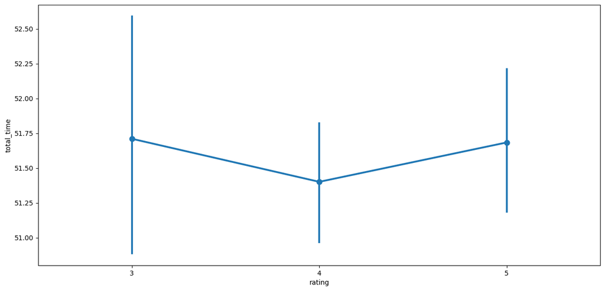

```python
# Relationship between rating and delivery time
plt.figure(figsize=(15, 7))
sns.pointplot(x = 'rating', y = 'total_time', data = data)
plt.show()
```

### Conclusion and Recommendations

### **Question 17:** What are your conclusions from the analysis? What recommendations would you like to share to help improve the business? (You can use cuisine type and feedback ratings to drive your business recommendations.) [6 marks]

### Conclusions:

- American is the popular cusine on weekends and weekdays
- Restaurant *Shake Shack* has the most number of orders and most number of ratings